# Replication of Hills 2009

Isaac Scheinfeld

2018-08-28

# Background

Questions

1. Are shared features sufficient to form meaningful categories?
2. Are some kinds of features more important than others?
3. Are perceptual or conceptual features more important for forming superordinate categories?
4. Are perceptual features a developmentally earlier source of categorical information?
5. Are conceptual features privileged in superordinate category formation?

Hills intends to “take the feature correlation approach to build network representations, and then use the formalisms of graph theory to examine the noun–feature relationships in terms of the structure they provide.” “By examining the small-world structure of early noun networks – as well as other graph- theoretic properties – we take a quantitative approach to evaluating the structural contributions of perceptual and conceptual features in the development of early categories.” “What is needed [] is a better understanding of [perceptual and conceptual features’] inter-related roles in a larger system of developing categories.”

Hills intends to address these specific questions:

1. Do features provide sufficient structure to infer common adult taxonomic categorizations among the nouns children know at 30 months of age?
2. If so, what are the available categories?
3. How robust are these categories to more or less stringent criteria for feature correlations?
4. Do perceptual and conceptual features differ in the structure they provide – are some feature types more robust, more discriminating, or more redundant?

# Preparation

This analysis requires a working copy of CFinder and the CFinder license in the same directory (necessary for running CFinder). The following must point to the command line executable:

```r
cfinder_program <- "./CFinder_commandline_mac"
```

## Nouns

Hills selected nouns from the Todler version of the MacArthur-Bates Communicative Developmental Inventory. This includes nouns which were aquired by 50% of children by 30 months. *This needs to be fixed to match Hills exactly*.

```r
# We begin by importing data from wordbank. Age of aquisition (in months, it starts with 16, 17,..) is that at which 50% of children can produce the word. We also do naive triming at this point, this means we are ignoring homophone/polysemy (chiken (food), chiken (animals), etc,.. but we will have to be careful in our choices if we are preparing later for publication.

full_vocab <- make_vocab_dataframe(lang="English (American)",
                                   lang_form = "WS",
                                   lex_class = "nouns") %>%
  trim_all_unilemma() %>%
  trim_all_definition() %>%
  arrange(age) %>%            # keep first age for duplicates arising from trimming
  distinct(uni_lemma, .keep_all = TRUE) %>%
  select(uni_lemma, definition, age, category)
```

The initial vocabulary contains 288 (compared to Hills’ 312).

## Features

Features taken from McRae et al. (2005), in which features were collected for 541 nouns from 725 adults, with 30 adults providing 14 features for each noun.

```r
vocab <- full_vocab %>%
  filter(age <= 30) %>%
  filter_to_features()
```

Only the words aquired by 30 months for which feature data are available are considered, an overlap of 113 in our data compared to Hills’ 130.

## Build Networks

Using vocabulary obtained by 30 months and the same MacRae features as Hills, we construct networks from perceptual and conceptual features. We track the number of features that generate each edge.

```r
perceptual_features = c("sound", "taste", "smell", "tactile",
                           "visual-form_and_surface", "visual-motion", "visual-color")
conceptual_features = c("function")

feature_links <-
  make_feature_links(vocab = vocab, feature_types = union(perceptual_features, conceptual_features))
perceptual_links <-
  make_feature_links(vocab = vocab, feature_types = perceptual_features)
conceptual_links <-
  make_feature_links(vocab = vocab, feature_types = conceptual_features)

feature_network <- graph_from_data_frame(feature_links, vertices = vocab, directed = FALSE) %>%
  as_tbl_graph() %E>%
  mutate(weight = shared) %>%
  set.graph.attribute("type", "Features") %>%
  set.graph.attribute("age", 30)

perceptual_network <- graph_from_data_frame(perceptual_links, vertices = vocab, directed = FALSE) %>%
  as_tbl_graph() %E>%
  mutate(weight = shared) %>%
  set.graph.attribute("type", "Perceptual") %>%
  set.graph.attribute("age", 30)

conceptual_network <- graph_from_data_frame(conceptual_links, vertices = vocab, directed = FALSE) %>%
  as_tbl_graph() %E>%
  mutate(weight = shared) %>%
  set.graph.attribute("type", "Conceptual") %>%
  set.graph.attribute("age", 30)
```

# Results

## Network statistics and small-world analyses

The network are shown in the following figure, for w = 1, 2, 3, and 4.

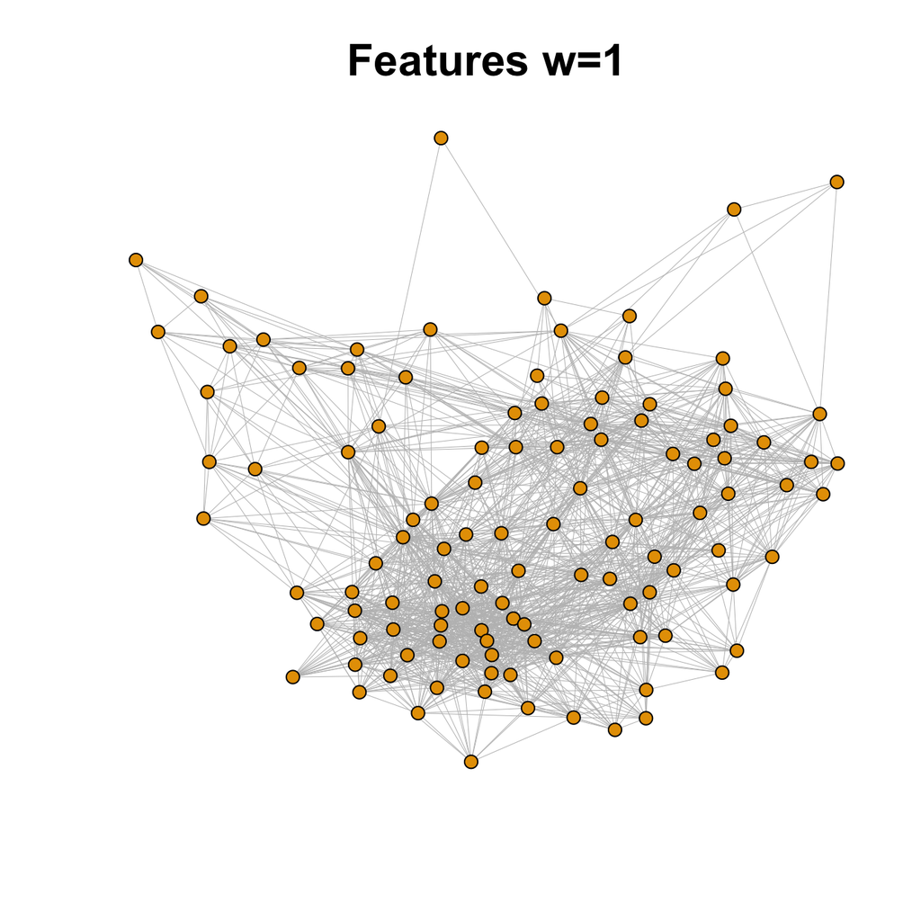

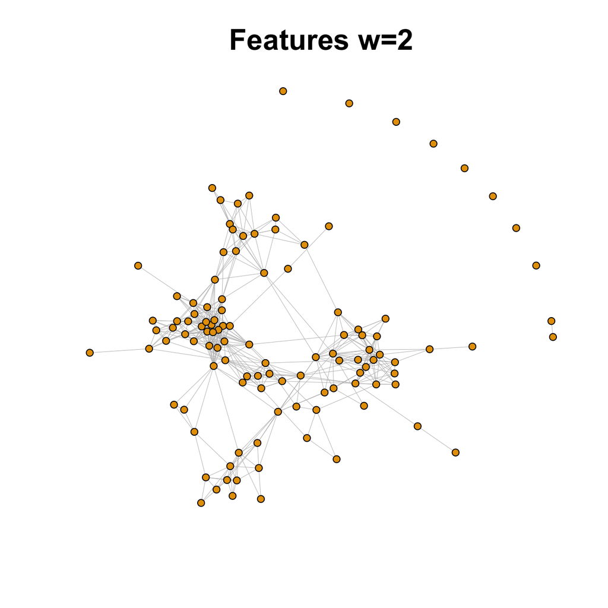

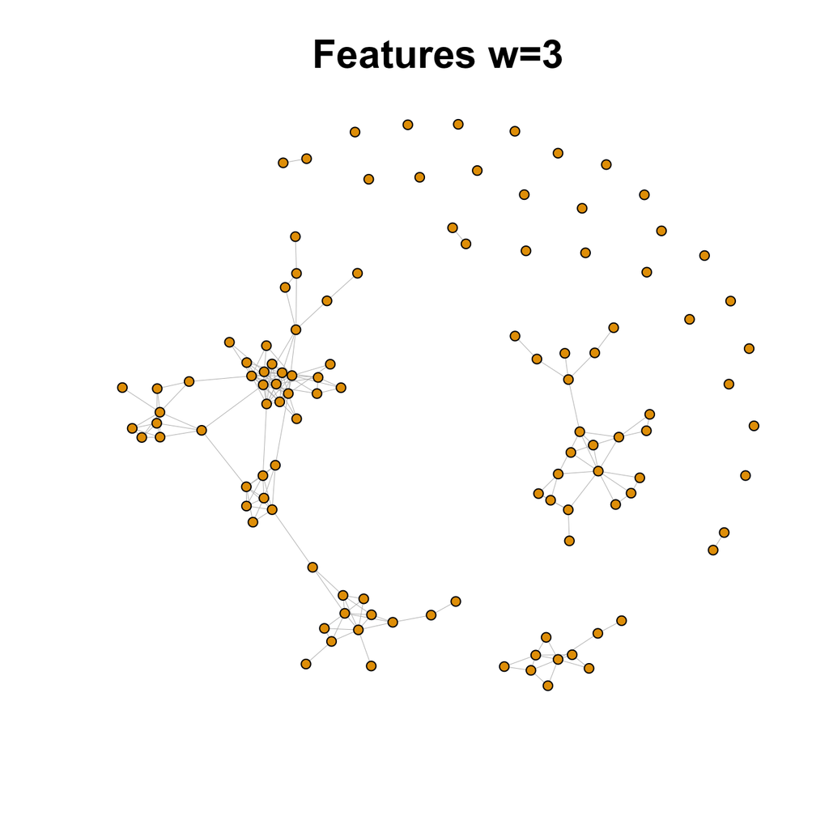

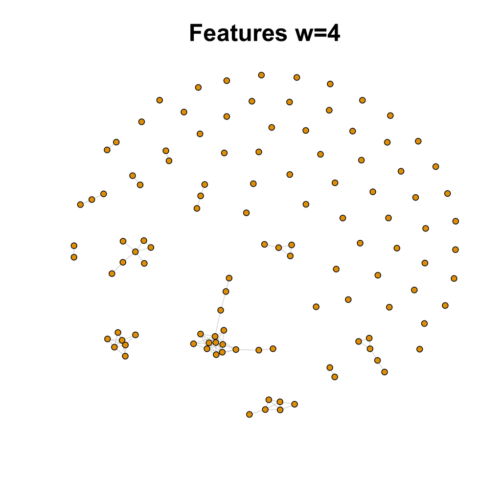

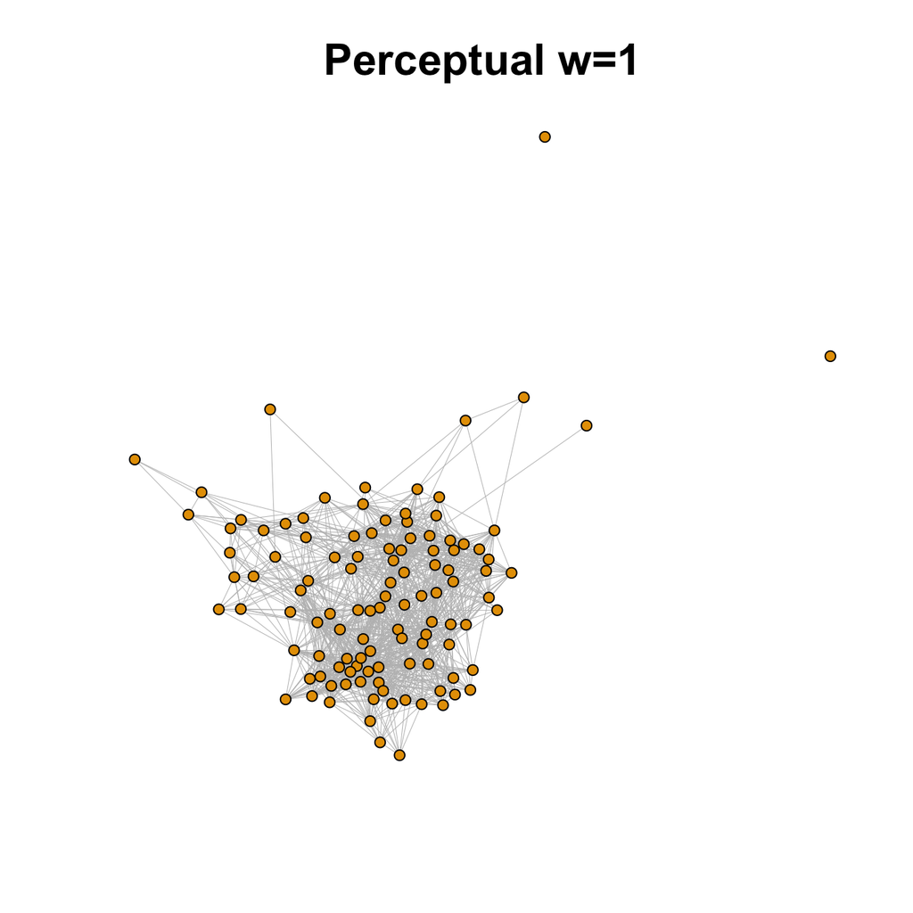

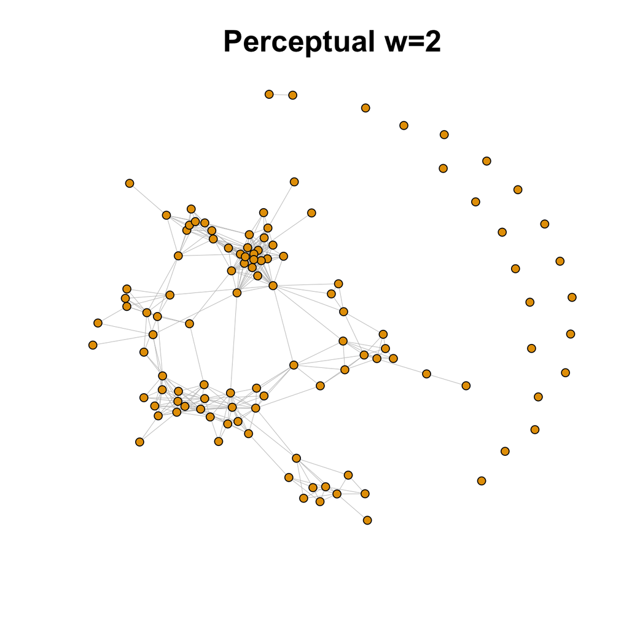

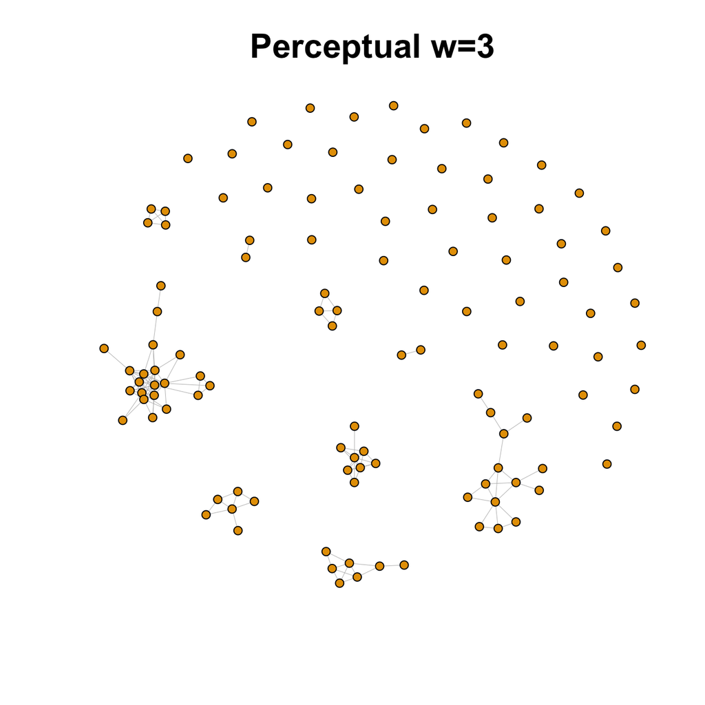

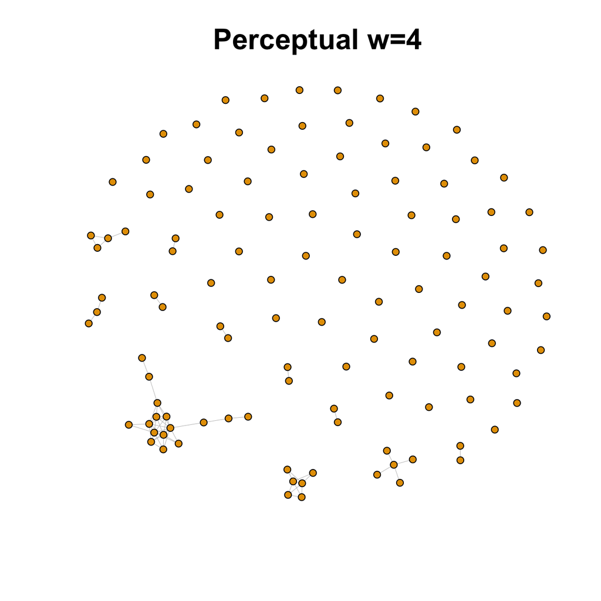

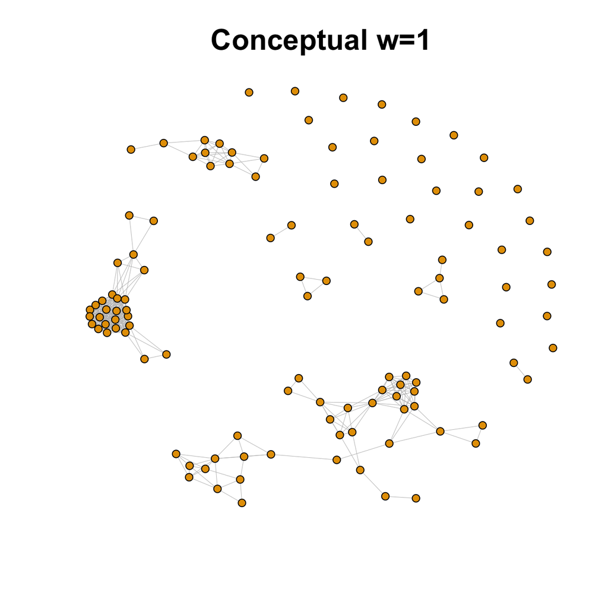

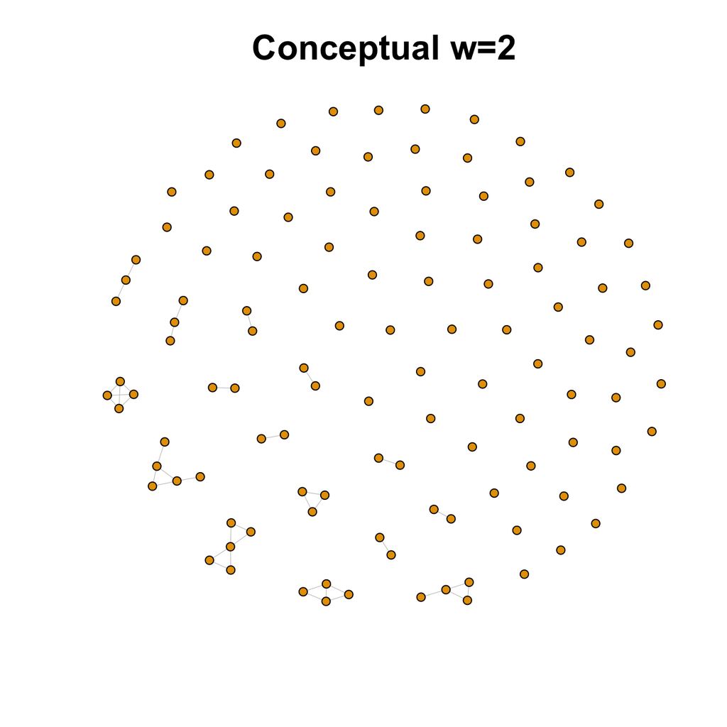

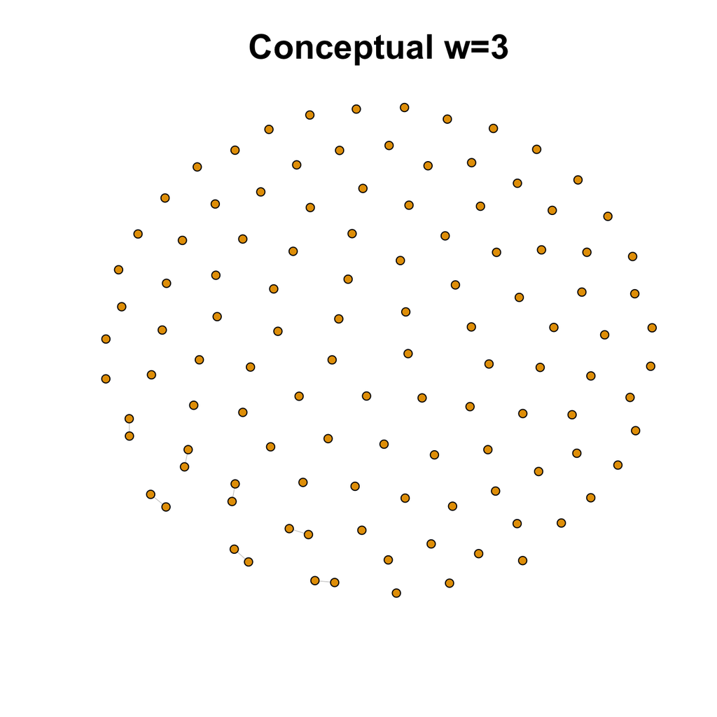

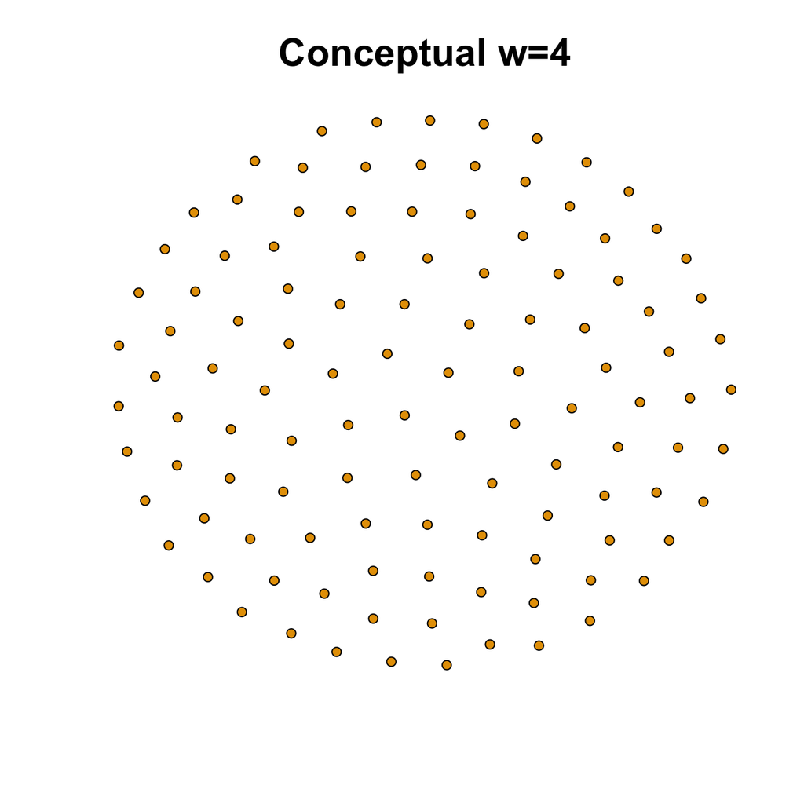

```r
par(oma=c(0,0,0.2,0))

for (network in list(feature_network, perceptual_network, conceptual_network)) {
  for (w in 1:4) {
    net <- network %E>% filter(shared >= w)
    layout <- layout_with_fr(net)
    plot_vocab_network(net, plot_title = title(str_glue("{net$type} w={w}"), cex.main=2), frame=FALSE, layout = layout, labels="")
  }
}
```

Some basic properties of networks built from perceptual and conceptual features.

```r
network_properties <- function(network) {
  return( tibble(
    type = network$type,
    age = network$age,
    w = network$w,
    vertices = vcount(network),
    edges = ecount(network),
    avg_degree = mean(degree(network)),
    avg_distance = mean_distance(network),
    diameter = diameter(network),
    clustering_coef = transitivity(network),
    density = edges / (vertices * (vertices - 1) / 2),
    clustering_coefficient_random = density,
    isolates = sum(degree(network) == 0),
    components = count_components(network) - isolates
  ))
}

max_w <- 4

feature_networks <- map(1:max_w, function(w) {
  feature_network %>%
    filter(shared >= w) %>%
    set.graph.attribute("w",w)})
perceptual_networks <- map(1:max_w, function(w) {
  perceptual_network %>%
    filter(shared >= w) %>%
    set.graph.attribute("w",w)})
conceptual_networks <- map(1:max_w, function(w) {
  conceptual_network %>%
    filter(shared >= w) %>%
    set.graph.attribute("w",w)})

networks <- feature_networks %>%
  append(perceptual_networks) %>%
  append(conceptual_networks)

properties <- bind_rows(map(networks, network_properties))
```

We can compare these networks to those from Hills, noting that we have a different set of words/nodes but that the induced subgraph of those words shared between our analysis and that of Hills should be the same.

```r
properties %>%
  mutate(h_clustering_coef = c(0.55, 0.54, 0.58, 0.60, 0.54, 0.54, 0.62, 0.62, 0.88, 0.59, 0.38, 1.00),
         h_avg_distance = c(1.72, 2.57, 4.96, 3.22, 1.76, 2.69, 5.02, 2.55, 3.08, 1.59, 5.02, 1.00),
         h_density = c(0.29, 0.10, 0.04, 0.02, 0.27, 0.08, 0.03, 0.01, 0.05, 0.01, 0.0, 0.0),
         h_components = c(1, 1, 4, 10, 1, 2, 8, 11, 7, 14, 7, 2),
         h_isolates = c(0, 6, 20, 47, 0, 10, 31, 69, 33, 81, 113, 126)) %>%
  select(type, age, w,
         clustering_coef, h_clustering_coef,
         avg_distance, h_avg_distance,
         density, h_density,
         components, h_components,
         isolates, h_isolates) %>%
  kable(format="html",
        escape = FALSE,
        col.names = c("Type", "age", "w",
                      "Clustering Coefficient", "",
                      "Average length", "",
                      "Density", "",
                      "Components", "",
                      "Isolates", ""),
        align = c("l", "l", "l", rep(c("r", "l"), 5)),
        digits = 2) %>%
  kable_styling(full_width = F) %>%
  column_spec(seq(5,13,2), color = "grey") %>%
  collapse_rows(columns = 1:2, valign = "top")
```

| Type | age | w | Clustering Coefficient |  | Average length |  | Density |  | Components |  | Isolates |  |
| --- | --- | --- | --- | --- | --- | --- | --- | --- | --- | --- | --- | --- |
| Features | 30 | 1 | 0.56 | 0.55 | 1.88 | 1.72 | 0.24 | 0.29 | 1 | 1 | 0 | 0 |
|  |  | 2 | 0.60 | 0.54 | 3.18 | 2.57 | 0.08 | 0.10 | 2 | 1 | 8 | 6 |
|  |  | 3 | 0.54 | 0.58 | 3.84 | 4.96 | 0.03 | 0.04 | 6 | 4 | 23 | 20 |
|  |  | 4 | 0.65 | 0.60 | 1.95 | 3.22 | 0.01 | 0.02 | 13 | 10 | 52 | 47 |
| Perceptual |  | 1 | 0.56 | 0.54 | 1.95 | 1.76 | 0.21 | 0.27 | 1 | 1 | 2 | 0 |
|  |  | 2 | 0.64 | 0.54 | 3.40 | 2.69 | 0.06 | 0.08 | 2 | 2 | 20 | 10 |
|  |  | 3 | 0.65 | 0.62 | 2.06 | 5.02 | 0.02 | 0.03 | 9 | 8 | 45 | 31 |
|  |  | 4 | 0.61 | 0.62 | 2.05 | 2.55 | 0.01 | 0.01 | 11 | 11 | 67 | 69 |
| Conceptual |  | 1 | 0.91 | 0.88 | 3.02 | 3.08 | 0.06 | 0.05 | 8 | 7 | 26 | 33 |
|  |  | 2 | 0.70 | 0.59 | 1.28 | 1.59 | 0.01 | 0.01 | 15 | 14 | 68 | 81 |
|  |  | 3 | NaN | 0.38 | 1.00 | 5.02 | 0.00 | 0.00 | 7 | 7 | 99 | 113 |
|  |  | 4 | NaN | 1.00 | NaN | 1.00 | 0.00 | 0.00 | 0 | 2 | 113 | 126 |

## Clique Percolation Clustering

### Full Network

Here we find parameter values for clique percolation according to the “principled approach” given in Hills, raising k for a given w until the the second largest cluster is greater than half the size of the largest, and then choosing the k for which this gives the most clusters.

```r
best_count <-  0
for (w in 1:5) {
  result <- cluster_cfinder(feature_network %E>% filter(shared >= w),
                            cfinder_program = cfinder_program)
  clusters <- result$clusters
  k <- result$k
  if (length(clusters) > best_count) {
    best_w <- w
    best_k <- k
    best_count <- length(clusters)
    best_clusters <- clusters
  }
}
```

This gives values of w=1 and k=8, as opposed to Hills’ w=3 and k=3, and gives the following clusters:

```r
title <- str_glue("Feature Network Clique Percolation Clusters, w = {best_w} and k = {best_k}")
kable_clusters(best_clusters, title)
```

| Feature Network Clique Percolation Clusters, w = 1 and k = 8 (7 Clusters) |
| --- |
| couch pants belt boots coat dress jacket gloves shirt |
| banana couch strawberry cheese bread lamb bed napkin pajamas pillow |
| boat comb hammer table banana airplane box couch tractor tricycle pants bus chicken garage horse pumpkin squirrel alligator peas strawberry apple orange pickle balloon cheese truck bread lamb chair ba… |
| boat hammer airplane tractor tricycle bus chicken helicopter horse squirrel train truck motorcycle car |
| comb table banana pen broom pants alligator belt hose stick boots coat dress pencil necklace |
| boat comb hammer table banana airplane box pen tractor tricycle broom door helicopter pumpkin spoon train hose peas apple orange pickle balloon basket brush bucket fork knife oven scissors shovel sink… |
| boat comb hammer table box pen broom door garage spoon stick pencil basket chair |

Note:  
Color indicates number of clusters in which a word occurs: 1 2 3 4

Hills’ values of w=3 and k=3 also give reasonable clusters:

```r
clusters <- cluster_cfinder(feature_network %E>% filter(shared >= 3),
                            k = 3,
                            cfinder_program = cfinder_program)$clusters
kable_clusters(clusters, "Feature Network Clique Percolation Clusters, w = 3 and k = 3")
```

| Feature Network Clique Percolation Clusters, w = 3 and k = 3 (10 Clusters) |
| --- |
| couch bed pillow |
| bowl fork spoon bucket brush broom |
| couch horse bear deer elephant lion tiger cat cow frog mouse pig pony sheep squirrel lamb dog zebra turtle |
| coat boots jacket jeans pants sweater dress shirt |
| spoon door hammer shovel |
| fork knife scissors |
| apple orange pickle strawberry banana cheese peas cake tuna |
| bowl cup dish plate |
| airplane bus train motorcycle tractor car truck tricycle |
| goose chicken owl rooster turkey duck penguin |

Note:  
Color indicates number of clusters in which a word occurs: 1 2

Note that this difference may be due to the minor differences between our networks. The largest cluster produced by w=3, k=3 is only one larger than twice the size of the second largest, and had it been smaller these parameters would have returned more clusters (and thus been selected) than w=1 and k=8. However, these minor differences do lead to substantially different clusterings.

### Perceptual Network

Here we find parameter values for clique percolation on the perceptual network.

```r
best_count <-  0
for (w in 1:5) {
  result <- cluster_cfinder(perceptual_network %E>% filter(shared >= w),
                            cfinder_program = cfinder_program)
  clusters <- result$clusters
  k <- result$k
  if (length(clusters) > best_count) {
    best_w <- w
    best_k <- k
    best_count <- length(clusters)
    best_clusters <- clusters
  }
}
```

This gives values of w=1 and k=8, as opposed to Hills’ w=2 and k=5, and gives the following clusters:

```r
title <- str_glue("Perceptual Network Clique Percolation Clusters, w = {best_w} and k = {best_k}")
kable_clusters(best_clusters, title)
```

| Perceptual Network Clique Percolation Clusters, w = 1 and k = 8 (7 Clusters) |
| --- |
| airplane chicken butterfly goose penguin turkey duck owl rooster |
| banana couch strawberry lamb cheese bed bread napkin pajamas pillow |
| airplane hammer chicken tractor tricycle bus helicopter horse train truck motorcycle car |
| comb table pen banana broom alligator hose stick pants pencil belt necklace boots coat dress |
| airplane comb hammer table box chicken tractor tricycle bus butterfly couch garage goose horse penguin pumpkin turkey alligator peas strawberry balloon boat truck lamb pants chair duck bathtub cow dee… |
| airplane comb hammer table box pen tractor tricycle banana broom door helicopter pumpkin spoon train hose peas balloon basket brush bucket fork knife oven scissors shovel sink stove apple bowl clock d… |
| comb hammer table box pen broom door garage spoon stick boat pencil basket chair |

Note:  
Color indicates number of clusters in which a word occurs: 1 2 3 4

Hills’ values of w=2 and k=5 also give reasonable clusters:

```r
clusters <- cluster_cfinder(perceptual_network %E>% filter(shared >= 2),
                            k = 5,
                            cfinder_program = cfinder_program)$clusters
kable_clusters(clusters, "Feature Network Clique Percolation Clusters, w = 2 and k = 5")
```

| Feature Network Clique Percolation Clusters, w = 2 and k = 5 (7 Clusters) |
| --- |
| pen bucket cup broom basket hammer brush comb fork knife scissors shovel spoon door |
| tractor train bus motorcycle car truck |
| coat jacket jeans pants shirt |
| pen hose broom belt stick pencil |
| chicken turkey airplane butterfly goose owl penguin rooster duck |
| pen bucket hose cup balloon bowl dish plate |
| chicken turkey horse bear couch cow deer elephant lamb lion squirrel table cat chair frog mouse pig pony sheep turtle zebra dog |

Note:  
Color indicates number of clusters in which a word occurs: 1 2 3

### Conceptual Network

Here we find parameter values for clique percolation on the conceptual network.

```r
best_count <-  0
for (w in 1:5) {
  result <- cluster_cfinder(conceptual_network %E>% filter(shared >= w),
                            cfinder_program = cfinder_program)
  clusters <- result$clusters
  k <- result$k
  if (length(clusters) > best_count) {
    best_w <- w
    best_k <- k
    best_count <- length(clusters)
    best_clusters <- clusters
  }
}
```

This gives values of w=1 and k=3, matching Hills’ w=1 and k=3, and gives the following clusters:

```r
title <- str_glue("Conceptual Network Clique Percolation Clusters, w = {best_w} and k = {best_k}")
kable_clusters(best_clusters, title)
```

| Conceptual Network Clique Percolation Clusters, w = 1 and k = 3 (11 Clusters) |
| --- |
| bed couch pillow |
| box closet garage |
| brush broom napkin |
| crayon pencil pen |
| oven cup stove |
| elephant lion tiger |
| crayon brush airplane boat bus helicopter horse motorcycle train tricycle ball doll toy balloon pony bathtub car truck |
| bowl basket bucket bottle |
| boots gloves jacket mittens sweater coat pants dress necklace shirt |
| elephant banana beans bread cake cheese chicken corn deer goose lamb peas pickle pig potato raisin rooster strawberry tuna turkey bear zebra cow sheep duck |
| bowl oven dish fork plate spoon |

Note:  
Color indicates number of clusters in which a word occurs: 1 2